# A Tutorial on Pincipal Component Analysis

GAO Zheng

Feb 2, 2017

This is a tutorial on applied principal component analysis. Minimal background on linear algebra is assumed. Notations roughly follow that of *Applied Multivariate Statistical Analysis* by R.A. Johndon and D.W.Wichern. Interactive display plotted with [Plotly](https://plot.ly).

# 1 A motivating example for data reduction

`mtcars` is a data frame with 32 observations on 11 variables. The data was extracted from the 1974 Motor Trend US magazine, and comprises fuel consumption and 10 aspects of automobile design and performance for 32 automobiles (1973–74 models). [^1]

Its columns are

- `mpg`: Miles/(US) gallon
- `cyl`: Number of cylinders
- `disp`: Displacement (cu.in.)
- `hp`: Gross horsepower
- `drat`: Rear axle ratio
- `wt`: Weight (1000 lbs)
- `qsec`: 1/4 mile time
- `vs`: V/S
- `am`: Transmission (0 = automatic, 1 = manual)
- `gear`: Number of forward gears
- `carb`: Number of carburetors

We will be working with only three of the columns: cylinder displacement, gross horsepower, and vihecle weight.

```r
mtcars3col <- mtcars[,c("disp","hp","wt")]
summary(mtcars3col)
```

|  | disp | hp | wt |
| --- | --- | --- | --- |
|  | Min. : 71.1 | Min. : 52.0 | Min. :1.513 |
|  | 1st Qu.:120.8 | 1st Qu.: 96.5 | 1st Qu.:2.581 |
|  | Median :196.3 | Median :123.0 | Median :3.325 |
|  | Mean :230.7 | Mean :146.7 | Mean :3.217 |
|  | 3rd Qu.:326.0 | 3rd Qu.:180.0 | 3rd Qu.:3.610 |
|  | Max. :472.0 | Max. :335.0 | Max. :5.424 |

We color the plot by transmission type. The plot is interactive, try give it a spin to see the data is 3D. (This may not work on your mobile phone.)

```r
mtcars$am[which(mtcars$am == 0)] <- 'Automatic'
mtcars$am[which(mtcars$am == 1)] <- 'Manual'
mtcars$am <- as.factor(mtcars$am)


p <- plot_ly(mtcars, x = ~hp, y = ~wt, z = ~disp, color = ~am, colors = c('#BF382A', '#0C4B8E')) %>%
  add_markers() %>%
  layout(scene = list(xaxis = list(title = 'Gross horsepower'),
                     yaxis = list(title = 'Weight'),
                     zaxis = list(title = 'Displacement')))
p
```

[interactive chart not shown]

It seems that most of the vairation is along a single direction (or two, depending on how sharp your eyes are). This phenomenon happens in many situations: in datasets with many vairiables (large p), the data points resides almost in a linear subspace of a much smaller dimension.

It is natural to ask:

1. Is there a way to represent the dataset is a way that is consistent with this observation? i.e., most of the variation happens in one (or a few) of the variables.
2. Is there a way, using linear combinations of the variables to represent the data without losing much information, so that we can work with fewer variables?

# 2 Population principal components

We have make precise what we mean by “summarize data in a few variables” and “not losing much information”.

Suppose we have a p-dimensional random vector $\mathbf{X}' = (X_1, X_2, \dots , X_p)$, we represent each data point as a collection o flinear combinations $Y$’s of its original data $X$’s.

$$Y_1 = a_1'X = a_{11}X_1 + \dots + a_{1p}X_p\\
Y_2 = a_2'X = a_{21}X_1 + \dots + a_{2p}X_p\\
\dots\\
Y_p = a_p'X = a_{p1}X_1 + \dots + a_{pp}X_p\\$$

In compact form,

$$Y = AX$$

where $A$ is a $p$ by $p$ matrix; $i^{th}$ row of A is $a_i'$.

We want most of the variation in the data $X$ to be summarized into as few components of $Y$’s as possible. Intuitively, we want variance of $Y_1$ to be as large as possible, and the variances of the rest of the $Y$’s in decreasing order.

A moments thought reveals that this cannont be done without contraints on $A$:

1. Scaling $a_1$ by a constant factor increase the variance of $Y_1$, leading to indeterminancy. We require that $a_i'a_i = 1$, i.e., $a_i$’s are unit vectors.
2. We also require that whatever has been explained in earlier $Y$’s does not re-enter later $Y$’s. We require $a_i'a_j = 0$, i.e., $a_i$ is orthogonal to $a_j$ whenever $i\ne j$. (It is in fact equivalent to require that the components of $Y$ are independent; left as an exercise).

The coefficients of the linear combinations therefore has the interpretation of a `direction’; each is direction orthogonal to the rest.

In two dimensions this is illustrated with the folloing plot. The two directions of linear combinations should be perpendicular to each other, with the first maximizing the variance of data along its direction.

[interactive chart not shown]

Formally, we can write the problem as a constrained optimization problem:

$a_1$ is the solution to

$$\begin{equation*}
\begin{aligned}
& \underset{a}{\text{max}}
& & \mathrm{Var}(a'X) \\
& \text{subject to}
& & a'a = 1
\end{aligned}
\end{equation*}$$

$a_2$ is the solution to

$$\begin{equation*}
\begin{aligned}
& \underset{a}{\text{max}}
& & \mathrm{Var}(a'X) \\
& \text{subject to}
& & a'a_1 = 0\\
& & & a'a = 1
\end{aligned}
\end{equation*}$$

In general the $j^{th}$ principal component is the solution to

$$\begin{equation*}
\begin{aligned}
& \underset{a}{\text{max}}
& & \mathrm{Var}(a'X) \\
& \text{subject to}
& & a'a_i = 0 & \mathrm{for} \; i = 1,\dots,j-1\\
& & & a'a = 1
\end{aligned}
\end{equation*}$$

It is exercise to show that the problem is equivalent to

$$\begin{equation*}
\begin{aligned}
& \underset{a}{\text{max}}
& & \frac{\mathrm{Var}(a'X)}{a'a} \\
& \text{subject to}
& & a'a_i = 0 & \mathrm{for} \; i = 1,\dots,j-1
\end{aligned}
\end{equation*}$$

Looks daunting, but luckily we can derive the solutions to the problem with some simple linear algebra.

$$\mathrm{Var}(a'X) = a'\mathrm{Var}(X)a = a'\Sigma_X a$$

where $\Sigma_X$ is the covariance matrix of $X$. Because $\Sigma_X$ is a [positive definite matrix](https://en.wikipedia.org/wiki/Positive-definite_matrix), it admits a [spectral decomposition](https://en.wikipedia.org/wiki/Eigendecomposition_of_a_matrix). we can write

$$\Sigma_X = P\Lambda P'$$
where $P = [v_1, \dots,v_p]$ is an [orthogonal matrix](https://en.wikipedia.org/wiki/Orthogonal_matrix), and $\Lambda$ a diagonal matrix with eigenvalues of $\Sigma_X$, $\lambda_1,\dots,\lambda_p$, in descending order as its diagonal entries.

If we write $b = P'a$, then

$$\begin{equation*}
\begin{aligned}
\frac{a'\Sigma_X a}{a'a} & = \frac{a' P\Lambda P'a}{a'PP'a} = \frac{b'\Lambda b}{b'b}
= \frac{\sum_{i=1}^{p}\lambda_i b_i^2}{\sum_{i=1}^{p} b_i^2}\\
& \le \lambda_1 \frac{\sum_{i=1}^{p} b_i^2}{\sum_{i=1}^{p} b_i^2}\\
& = \lambda_1
\end{aligned}
\end{equation*}$$

where equality can be attained when $a$ is a constant multiple of $v_1$. Say $a = v_1$ so $b = P'a = (1,0,\dots,0)'$ since by orthogonality of $P$,

$$b = P'a = \begin{bmatrix}v_1'\\v_2'\\\vdots\\v_p'\end{bmatrix} v_1 = \begin{bmatrix}1\\0\\\vdots\\0\end{bmatrix}$$

We have solved the optimization problem for the first principal component.

Similar arguments work for the rest of the problems.

For the $j^{th}$ problem we require that $a\perp a_i \; \mathrm{for}\; i = {1,\dots,j-1}$, so the optimizing $a$ must be in the span of $v_j,\dots,v_p$, i.e., $a = b_j v_j + \dots + b_p v_p$, for some $b_j,\dots,b_p$.

(Note that we have not abused notations here since $b_k = (P'a)_k = (P')_{k*}a = (P)_{*k}'a = v_k'a = v_k'(b_j v_j + \dots + b_p v_p) = b_k$.)

The objective function simplifies to

$$\begin{equation*}
\begin{aligned}
\frac{a'\Sigma_X a}{a'a} & = \frac{a' P\Lambda P'a}{a'PP'a} = \frac{b'\Lambda b}{b'b}
= \frac{\sum_{i=j}^{p}\lambda_i b_i^2}{\sum_{i=j}^{p} b_i^2}\\
& \le \lambda_j \frac{\sum_{i=j}^{p} b_i^2}{\sum_{i=j}^{p} b_i^2}\\
& = \lambda_j
\end{aligned}
\end{equation*}$$

Setting $a = v_j$ and $b = P'a = \underbrace{(0,\dots,0,1,0,\dots,0)}_{j^{th} \text{ unit vector}}$ attains the maximum.

To summarize, the the principal components are exactly the eigenvectors of the covariance matrix of $X$, corresponding to the eigenvalues in decreasing order.

An interesting consequence of the decomposition is that the sum of variances are preserved.

$$\begin{aligned}
\sum_{i=1}^{p}\mathrm{Var}(Y_i)
& = \sum_{i=1}^{p} \lambda_i = \mathrm{tr}(\Lambda) = \mathrm{tr}(P'P\Lambda)\\ & = \mathrm{tr}(P\Lambda P')\\
& = \mathrm{\Sigma_X} = \sum_{i=1}^{p}\mathrm{Var}(X_i)
\end{aligned}$$

where the second line uses the fact that trace is cyclic invariant.

This allows us to quantify in a sense how how variability in the data is captured by each of the transformed variables.

$$\begin{bmatrix}
\text{proportion of variation}\\
\text{ captured by the}\\
i^{th}\text{ principal component}
\end{bmatrix} = \frac{\lambda_i}{\lambda_1 + \dots + \lambda_p}$$

Sometimes a [scree plot](http://support.minitab.com/en-us/minitab/17/topic-library/modeling-statistics/multivariate/principal-components-and-factor-analysis/what-is-a-scree-plot/) is helpful as a visual representation. We will see an example later.

The transformed variables $Y_i$’s are sometimes called PC-scores, denoted as $\text{PC}_1,\dots,\text{PC}_p$.

Since A is an orthogonal matrix, $A' = A^{-1}$, we can recover the original variables by

$$X = A'Y$$

When variances of the later coordinates of $Y$ are small, reconstruction can be done approximately using only the first few PC-scores with large variances. More on this in the exmaple.

You may have noticed that we have not used any normality assumptions on the random vector $X$. The above derivation is distribution-free.

# 3 Estimation of principal components

Now we have a sample of random vectors $x_1, \dots, x_n$, each from the p-dimensional distribution with mean $\mu$ and covariance matrix $\Sigma$.

When the two population parameters are unknown, We can form the sample estimates by

$$\hat\mu = \bar{x}\in {\rm I\!R}^p\\$$
and
$$\hat\Sigma
= S
= \frac{1}{n-1}\sum_{i=1}^{n}(x_i-\bar{x})(x_i-\bar{x})' \in {\rm I\!R}^{p\times p}$$

Estimation of the principal components follow that of the derivation in the population version. This is a `plug-in’ version of the derivation eariler.

$$\hat{v_i} = i^{th}\text{ eigenvector of sample covariance matrix}$$

Sample variances are estimated as corresponding eigenvalues of sample covariance matrix, $\hat\lambda_i$’s.

## 3.1 Large sample properties of $\hat\lambda_i$ and $\hat{v}_i$

We only briefly mention here asymptotic results under i.i.d. normality assumptions, [^2]

1. $\sqrt{n}(\hat\lambda-\lambda)$ is distributed approximately $N_p(0,2\Lambda^2)$.
2. $\sqrt{n}(\hat v_i-v_i)$ is distributed approximately $N_p(0,E_i)$. where
   $$E_i = \lambda\sum_{k\ne i}\frac{\lambda_k}{(\lambda_k-\lambda_i)^2}v_kv_k'$$

Approximate confidence intervals may be formed using these results.

Note that we always assume $n>p$ and the sample covariance matrix is positive definite. The `mordern’ case where $n<p$ is more complicated to analyze analytically.

# 4 Back to the example

Lets estimate principal components of the car data that we introduced earlier.

```r
centered <- scale(mtcars3col, center = T, scale = F)
S <- t(centered) %*% centered / (nrow(centered) - 1)
eigen(S)
```

```
## $values
## [1] 1.860958e+04 1.452843e+03 1.976047e-01
##
## $vectors
##             [,1]        [,2]         [,3]
## [1,] 0.900358831  0.43507942 -0.007737573
## [2,] 0.435103429 -0.90037894  0.001662354
## [3,] 0.006243492  0.00486336  0.999968683
```

R has a built-in function `prcomp` in `stats` package that does this automatically. `stats` should have been loaded on launching R be default.

```r
(mtcarsPCA <- prcomp(mtcars3col))
```

```
## Standard deviations:
## [1] 136.4169490  38.1161718   0.4445275
##
## Rotation:
##              PC1         PC2          PC3
## disp 0.900358831  0.43507942 -0.007737573
## hp   0.435103429 -0.90037894  0.001662354
## wt   0.006243492  0.00486336  0.999968683
```

The promised scree plot:

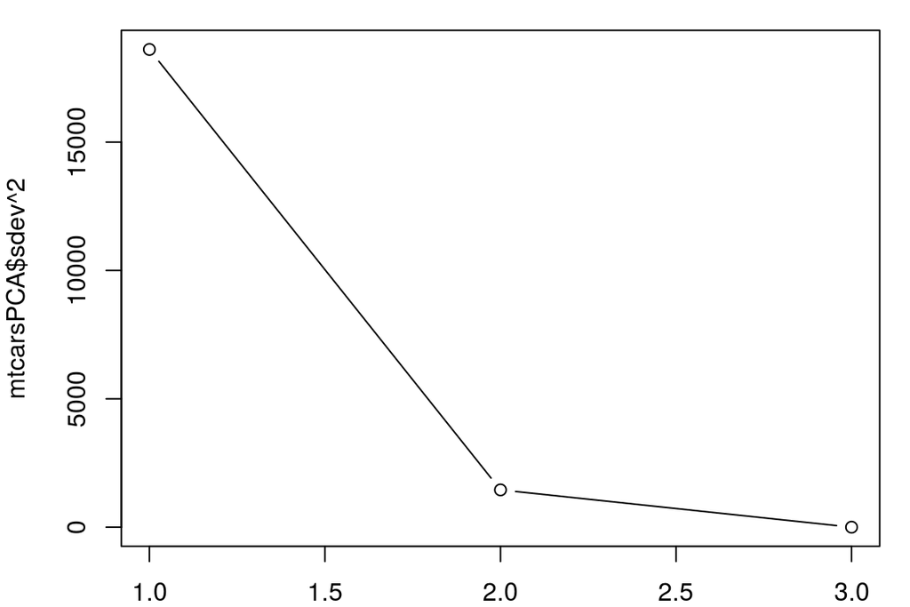

```r
par(mar = c(2,4,1,1))
plot(mtcarsPCA$sdev^2, type = 'b')
```

first component explained 0.9275748 of the variations in the data, consistent with our initial observarion that variations in a single direction is dominating.

## 4.1 Number of principal components

The implication of the above finding is that one can represent the data using fewer dimensions without losing much of the information.

In the `mtcars` example one could potentially use a single number that is the linear combination of cylinder displacement, gross horsepower, and vihecle weight for each data point, and achieve a 67% saving in terms of storage.

The 1st PC-score for the $i^{th}$ obsercation is

$$\begin{aligned}
\text{PC}_{i,1} & = v_1' (x_1 - \bar{x}) \\
& = 0.900 * (\text{disp}-\bar{\text{disp}}) + 0.435 * (\text{hp} - \bar{\text{hp}}) + 0.006 * (\text{wt} - \bar{\text{wt}})
\end{aligned}$$

To recover the original variables approximately using only the first PC-score,

$$\begin{bmatrix}\text{disp}\\\text{hp}\\\text{wt}\end{bmatrix}_i
\approx \text{PC}_{i,1}\hat v_1 +
\begin{bmatrix}\bar{\text{disp}}\\\bar{\text{hp}}\\\bar{\text{wt}}\end{bmatrix}
= \text{PC}_{i,1} \begin{bmatrix}0.900\\0.435\\0.006\end{bmatrix} +
\begin{bmatrix}\bar{\text{disp}}\\\bar{\text{hp}}\\\bar{\text{wt}}\end{bmatrix}$$

In general the number of principal component to use can be chosen by looking at the scree plot. We look for an ‘elbow’ in the plot, where much of the variation in the data are contained in the PC’s that come before the ‘elbow’.

## 4.2 PCA on standardized data

The PC loading of the first component on the third variable in this example is extremely small compared to the other two coordinates. This is an artifact of the difference in unit of measurement in the three variables, and the lack of standardization before we performed the procedure.

The measurements in the variables are by nature orders of magnitudes apart. If we choose to preserve the overall distance structure of the dataset, the measurements that are smaller are naturally disadvantaged. In recovery the relative errors are larger on variables originally on smaller scales.

To correct for this artificial preference, we can perform PCA on the standardized dataset.

```r
(mtcarsPCAstd <- prcomp(mtcars3col, scale. = T))
```

```
## Standard deviations:
## [1] 1.6006801 0.5934455 0.2926530
##
## Rotation:
##            PC1        PC2        PC3
## disp 0.6054746 -0.1556735  0.7804910
## hp   0.5493793  0.7913073 -0.2683562
## wt   0.5758323 -0.5912685 -0.5646403
```

Now the first component explained 0.8540589 of the variations in the data, but the loadings are much more comparable.

One may want to think about if it even makes sense to PCA on variables with different units for interpretation. (What does it mean when we add, say distance^2 to seconds^2?)

## 4.3 Interpretation

Interpretation of the PCs is a little difficult. I find geometric interpretation of the PCs most fruitful.

In the 2D synthetic data example above, the first PC indicates a positive correlation between the two variables, with most variations taking place along its directions. Scales of the standard deviations gives us a sense of how much the variation is accounted for.

In the 3D real data example (for the standardized version), the first PC $(0.605, 0.549, 0.576)$ also points to a positive quadrant in the direction of the largest variation, indicating for cars higher horse powers are assciated with heavier weight and larger engine displacement. Second PC indicates a negative relationship between horsepower and the other two variables, after accounting for the co-movement described in the first PC.

## 4.4 Practical issues and questions

1. What to do when there is categorical variable in the data?
2. Standardization or no standardization?

# 5 Q&A

[^1]: Henderson and Velleman (1981), Building multiple regression models interactively. *Biometrics*, **37**, 391–411.
[^2]: Anderson, T. W. Asymptotic Theory for Principal Component Analysis. Ann. Math. Statist. 34 (1963), no. 1, 122–148. doi:10.1214/aoms/1177704248. http://projecteuclid.org/euclid.aoms/1177704248.